# The Data Incubator Fellowship Program

Chart 2 & Modeling

Andrej Arpáš

5/14/2020

# Outline

For more info, please see [Chart 1](https://arpasan.github.io/misc/tdifp_chart1.html).

Second plot…

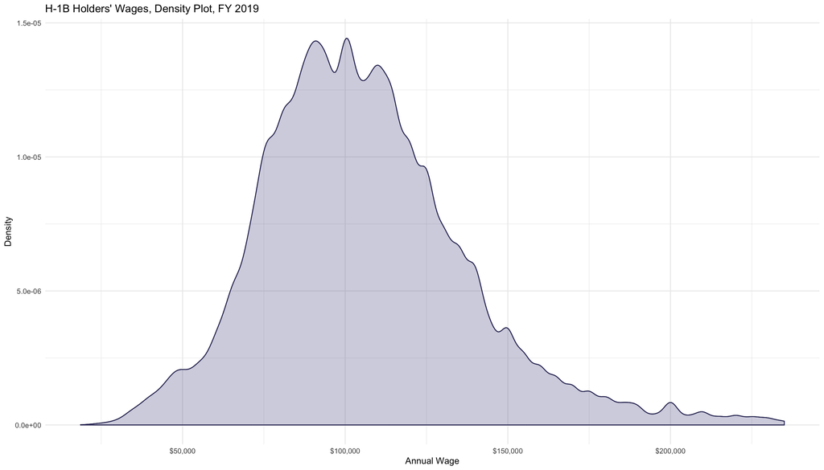

# Logged Wages: A Simple Model in Stan

wage ~ emp_size + fw_edu + fw_edu_name

Expose some Stan functions…

```r
rstan::expose_stan_functions("quantile_functions.stan")
```

```
## Trying to compile a simple C file
```

```r
source("GLD_helpers.R")
```

Set up the priors…

```r
m_alpha <- log(100000) # Normal prior stuff for alpha. Mean.
s_alpha <- 0.15 # Standard deviation.

# GLD priors for coefficients...
medians <- c(ES = 0.05, E = 0.06, S = 0.10) # ES employer's size, E education, S school.
lowers <- c(ES = 0.03, E = 0.03, S = 0.07)
uppers <- c(ES = 0.07, E = 0.09, S = 0.13)
ninety <- c(ES = 0.10, E = 0.11, S = 0.15)
a_s <- lapply(1:length(medians), FUN = function(i) {
  GLD_solver(lowers[i], medians[i], uppers[i], ninety[i], alpha = 0.9)
  }) # Some warnings about bounded tails.
names(a_s) <- names(medians)


# JQPDS prior stuff for sigma...
q_sigma <- c(lower = 0.25, median = 0.5, upper = 1) # Quantiles / What I think.
```

We do some recoding on the data to speed up the evaluation. We want to further recode the education levels to something ordered, going from Bachelor’s, through Master’s, and PhD. Insofar as the schools go, we divvy the set up into four tiers, roughly, depending on the league tables: (i) Not-in-Ranking/Lowest Tier, (ii) U.S. Lower Tier, (iii) U.S. Middle Tier, and (iv) U.S. Ivies. We shall hone in on the schools with 1000 graduates or more (from among the foreign workers in the dataset). These are…

```r
# SOME RECODING...

# Subset and random sample for memory capacity/speed issues...
d.sub.b <- subset(d.sub, select = c("emp_size", "wage", "fw_cob",
                                    "fw_edu", "fw_edu_name"))

# Filter for only the schools where at least 1,000 people went...
d.sub.b %>% group_by(fw_edu_name) %>% tally() %>% arrange(desc(n)) %>% filter(n > 1000) %>% print(n = Inf)
```

```
## # A tibble: 39 x 2
##    fw_edu_name                                         n
##    <fct>                                           <int>
##  1 JAWAHARLAL NEHRU TECHNOLOGICAL UNIVERSITY        9874
##  2 ANNA UNIVERSITY                                  8646
##  3 OSMANIA UNIVERSITY                               4735
##  4 UNIVERSITY OF MADRAS                             4699
##  5 UNIVERSITY OF SOUTHERN CALIFORNIA                4413
##  6 CARNEGIE MELLON UNIVERSITY                       3576
##  7 UNIVERSITY OF MUMBAI                             3325
##  8 UNIVERSITY OF PUNE                               3140
##  9 ANDHRA UNIVERSITY                                2695
## 10 VISVESWARAIAH TECHNOLOGICAL UNIVERSITY, BELGAUM  2587
## 11 COLUMBIA UNIVERSITY                              2177
## 12 SAN JOSE STATE UNIVERSITY                        2150
```

[output cut: 27 more lines]

```r
schools <- d.sub.b %>% group_by(fw_edu_name) %>% tally() %>% arrange(desc(n)) %>% filter(n > 1000) %>% select(fw_edu_name)
d.sub.b <- d.sub.b %>% filter(fw_edu_name %in% schools$fw_edu_name) #%>% print()

(.01 * nrow(d.sub.b)) # 1% of the original data is ~925 rows.
```

```
## [1] 925.01
```

```r
d.sub.rs <- d.sub.b[sample(nrow(d.sub.b), size = 925, replace = FALSE), ] # Random sample of d.sub.b.

d.sub.c <- d.sub.rs
d.sub.c$fw_cob <- NULL

# Recoding...
d.sub.c$fw_edu <- as.numeric(factor(d.sub.c$fw_edu, order = TRUE,
                                    levels = c("BACHELOR'S", "MASTER'S", "DOCTORATE"),
                                    labels = c(1:3)))

d.sub.c$fw_edu_name <- as.numeric(factor(d.sub.c$fw_edu_name, order = TRUE,
                                         levels = c("JAWAHARLAL NEHRU TECHNOLOGICAL UNIVERSITY", "ANNA UNIVERSITY", "OSMANIA UNIVERSITY", # No-ranking schools.
                                                    "UNIVERSITY OF MADRAS", "UNIVERSITY OF MUMBAI", "UNIVERSITY OF PUNE",
                                                    "ANDHRA UNIVERSITY", "VISVESWARAIAH TECHNOLOGICAL UNIVERSITY, BELGAUM",
                                                    "VISVESWARAIAH TECHNOLOGICAL UNIVERSITY", "BHARATHIDASAN UNIVERSITY", "UTTAR PRADESH TECHNICAL UNIVERSITY",
                                                    "BHARATHIAR UNIVERSITY", "MADURAI KAMARAJ UNIVERSITY", "ANNA UNIVERSITY CHENNAI",
                                                    "ACHARYA NAGARJUNA UNIVERSITY", "BANGALORE UNIVERSITY", "KAKATIYA UNIVERSITY",
                                                    "INDIRA GANDHI NATIONAL OPEN UNIVERSITY", "SRI VENKATESWARA UNIVERSITY",

                                                    "UNIVERSITY OF SOUTHERN CALIFORNIA", "THE UNIVERSITY OF TEXAS AT DALLAS", "SAN JOSE STATE UNIVERSITY", # U.S. lower-tier.
                                                    "NORTH CAROLINA STATE UNIVERSITY", "ARIZONA STATE UNIVERSITY", "NORTHEASTERN UNIVERSITY",
                                                    "ILLINOIS INSTITUTE OF TECHNOLOGY", "STATE UNIVERSITY OF NEW YORK AT BUFFALO", "PURDUE UNIVERSITY",
                                                    "SYRACUSE UNIVERSITY", "UNIVERSITY OF FLORIDA", "NEW JERSEY INSTITUTE OF TECHNOLOGY",

                                                    "TEXAS A&M UNIVERSITY", "CARNEGIE MELLON UNIVERSITY", "NEW YORK UNIVERSITY", # U.S. middle-tier.
                                                    "GEORGIA INSTITUTE OF TECHNOLOGY", "UNIVERSITY OF MICHIGAN",

                                                    "COLUMBIA UNIVERSITY", "CORNELL UNIVERSITY", "UNIVERSITY OF PENNSYLVANIA"), # U.S. Ivies.
                                        labels = c(rep(1, 19), rep(2, 12), rep(3, 5), rep(4, 3))))
d.sub.c <- d.sub.c %>% drop_na() #%>% tally()
```

## Model Matrix

Now, we’re ready to set up our model.matrix()…

```r
# Set up the X matrix and center it...
X <- model.matrix(log(wage) ~ emp_size + fw_edu + fw_edu_name,
                  data = d.sub.c)[ , -1] # Drop the intercept because we handle it ourselves.

X <- sweep(X, MARGIN = 2, STATS = colMeans(X), FUN = `-`) # Center the columns.
```

## Prior Predictive Distribution (PPD)

Drawing from the PPD, which is the marginal distribution of future data integrated over the parameters…

```r
# Ready to draw from the prior predictive distribution (PPD) of log-wages...
PPD <- replicate(1000, {
  alpha_ <- rnorm(1, mean = m_alpha, sd = s_alpha)

  beta_ES_ <- GLD_rng(medians["ES"], IQR = uppers["ES"] - lowers["ES"], asymmetry = a_s$ES[1], steepness = a_s$ES[2])
  beta_E_ <- GLD_rng(medians["E"], IQR = uppers["E"] - lowers["E"], asymmetry = a_s$E[1], steepness = a_s$E[2])
  beta_S_ <- GLD_rng(medians["S"], IQR = uppers["S"] - lowers["S"], asymmetry = a_s$S[1], steepness = a_s$S[2])

  mu_ <- alpha_ + beta_ES_ * X[ , "emp_size"] + beta_E_ * X[ , "fw_edu"] + # Priors on the coefficients.
         beta_S_ * X[ , "fw_edu_name"]

  sigma_ <- JQPDS_rng(lower_bound = 0, alpha = 0.25, quantiles = q_sigma) # Drawn from a normal distribution.

  epsilon_ <- rnorm(length(mu_), mean = 0, sd = sigma_) # Some error term.

  y_ <- mu_ + epsilon_
  y_
})
# round(quantile(c(exp(PPD)), probs = 1:9 / 10), digits = 3)
```

## Prior Distribution

Drawing from the prior…

```r
# Prior (not predictive) distribution...
R_squared <- replicate(1000, {
  alpha_ <- rnorm(1, mean = m_alpha, sd = s_alpha)

  beta_ES_ <- GLD_rng(medians["ES"], IQR = uppers["ES"] - lowers["ES"], asymmetry = a_s$ES[1], steepness = a_s$ES[2])
  beta_E_ <- GLD_rng(medians["E"], IQR = uppers["E"] - lowers["E"], asymmetry = a_s$E[1], steepness = a_s$E[2])
  beta_S_ <- GLD_rng(medians["S"], IQR = uppers["S"] - lowers["S"], asymmetry = a_s$S[1], steepness = a_s$S[2])

  mu_ <- alpha_ + beta_ES_ * X[ , "emp_size"] + beta_E_ * X[ , "fw_edu"] + # Priors on the coefficients.
         beta_S_ * X[ , "fw_edu_name"]

  sigma_ <- JQPDS_rng(lower_bound = 0, alpha = 0.25, quantiles = q_sigma) # Drawn from a normal distribution.

  numer <- var(mu_)
  denom <- sigma_^2 + numer
  R_squared <- numer / denom
  R_squared
})
# summary(R_squared)
```

## Posterior Distribution

Using stan_lm() to draw from the posterior…

```r
# Drawing from the Posterior Distribution...
library(rstanarm)
post <- stan_lm(log(wage) ~ emp_size + fw_edu + fw_edu_name, data = d.sub.c,
                prior = R2(location = median(R_squared), what = "median"),
                prior_intercept = normal(location = m_alpha, scale = s_alpha, autoscale = FALSE))
print(post, digits = 2)
```

```
## stan_lm
##  family:       gaussian [identity]
##  formula:      log(wage) ~ emp_size + fw_edu + fw_edu_name
##  observations: 905
##  predictors:   4
## ------
##             Median MAD_SD
## (Intercept) 11.50   0.02
## emp_size     0.00   0.00
## fw_edu      -0.02   0.02
## fw_edu_name  0.06   0.01
##
## Auxiliary parameter(s):
##               Median MAD_SD
## R2            0.04   0.01
## log-fit_ratio 0.00   0.02
## sigma         0.23   0.01
##
## ------
## * For help interpreting the printed output see ?print.stanreg
## * For info on the priors used see ?prior_summary.stanreg
```

## Model Evaluation

```r
library(loo)
loo(post)
```

```
##
## Computed from 4000 by 905 log-likelihood matrix
##
##          Estimate   SE
## elpd_loo     35.4 22.3
## p_loo         4.8  0.4
## looic       -70.8 44.6
## ------
## Monte Carlo SE of elpd_loo is 0.0.
##
## All Pareto k estimates are good (k < 0.5).
## See help('pareto-k-diagnostic') for details.
```

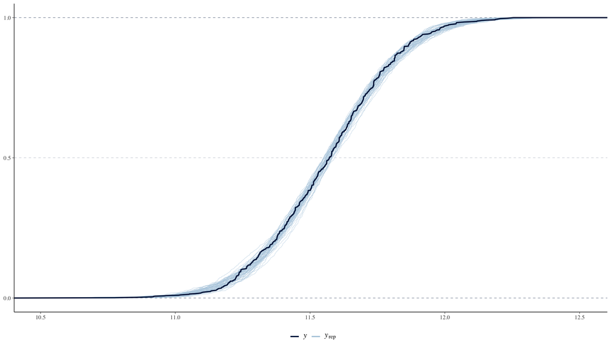

```r
library(bayesplot)
pp_check(post, plotfun = "ecdf_overlay") + legend_move("bottom")
```

Does an okay job on the fit even though I choose totally non-informative priors. (Or rather mildly informative priors that were all ill-informed.)